# Outline of eDiscovery paper

Richard Careaga

February 8, 2019

# Introduction

## Goal

The goal of this paper is to illustrate a combination of machine learning, natural language processing and graph analysis techniques applied to corporate email to identify potential witnesses in litigation.

# Background

> In times of political turmoil, events can move from impossible to inevitable without even passing through improbable. [Anatole Kalesky](https://www.project-syndicate.org/commentary/canceling-brexit-becoming-inevitable-by-anatole-kaletsky-2018-12)

[Enron Corp.](https://en.wikipedia.org/wiki/Enron) and its affiliates were engaged in energy-related businesses, as described in its [Annual Report on Form 10-K for the year ended December 31, 2000](https://www.sec.gov/Archives/edgar/data/1024401/000102440101500010/ene10-k.txt)

For the year ended December 31, 2000, it had operating revenues of $100,789 million, according to the same report.

On December 2, 2001, Enron filed for bankruptcy protection.

In less than a year, Enron underwent a complete reversal of fortune as its business strategies ran afoul of applicable regulations, among which were those of the Federal Energy Regulatory Commission (**FERC**).

FERC [became aware](https://www.ferc.gov/industries/electric/indus-act/wec/chron/chronology.pdf) of irregularities in the California wholesale electricity market prices. An orientation to the issues is provided by [testimony](https://web.stanford.edu/group/fwolak/cgi-bin/sites/default/files/files/2002,%20May%2015_Senate%20Committee%20on%20Commerce,%20Science%20and%20Transportation_Wolak.pdf) before FERC, which provides a concise summary.[^1]

Following Enron’s bankruptcy, FERC began an intense investigation, including the email records of 149 Enron employees. A preliminary [staff report](http://elibrary.ferc.gov/idmws/common/opennat.asp?fileID=9548231) issued six months later.

## Motivating Data

FERC obtained approximately 500,000 emails. Copies of these were acquired by Leslie Kaelbling of MIT and [published](https://www.cs.cmu.edu/~./enron/) by William W. Cohen of Carnegie Mellon University. It is one of the largest publicly available datasets of corporate email and is referred to as the Enron Corpus. The term *corpus* is used in natural language processing to denote a collection of related text.

At the time, electronic record examination (*ediscovery*) in litigation was in a primitive state. It was not uncommon, for example, for paper copies of email to be offered. These would typically be read by teams of freelance attorneys looking for keywords. Advanced technology included scanning with optical character recognition and some proprietary software options to organize emails and capture the status of review. Much of the focus was directed to keyword searches, sometimes called the *smoking gun* approach. Brute force examination misses opportunities to understand the social networks that reflect how the organization operates, what their concerns are and the haphazard exposure of document reviewers inevitably poses the [Elephant and the Blind Men Problem](https://buddhismnow.com/2018/02/16/tittha-sutta-buddhist-parable-of-the-blind-men-and-the-elephant/). To triage the corpus quickly and efficiently, it should first be be distilled and analyzed.

# Analysis

## Data acquisition

I obtained a copy of the 2009 version of the corpus. It contains copies of emails of a private nature that involve three users have who since requested to be [redacted](https://www.cs.cmu.edu/~./enron/DELETIONS.txt). I have removed those 27 emails.[^2]

### Conversion

Each email was a plaintext file[^3] Each user had a directory tree similar to the one below.[^4]

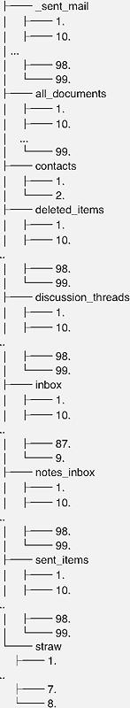

Typical user data tree

Although tedious, traversing the directory tree, parsing the emails and loading them into an SQL database, was accomplished with a combination of Python and Perl scripting and standard bash tools. I do not reproduce that process here as it has little bearing on the main topic of this paper.

### Data structure

While the emails were not in native format, the plain text versions contained nine principal segments, as shown in the figure below

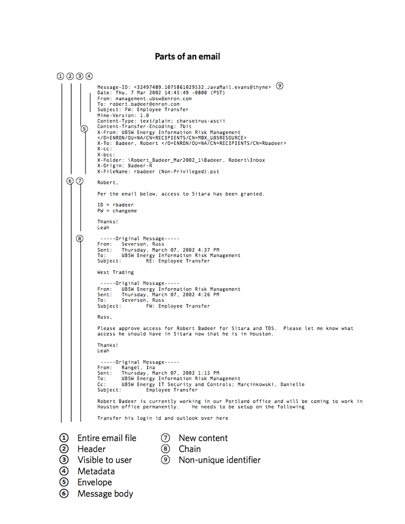

Structural analysis of an Enron email

Of those, the following were extracted from my earlier analysis for this paper:

- sender
- date
- subject
- recipient(s)
- message body
- new content

### Deduplication

Using scripting tools, each text file extraction created a *payload* of the new content in the related email, capturing the text between the beginning metadata and the following metadata for email purposes. A `payload` hash, an [md5](https://en.wikipedia.org/wiki/MD5) encoded message digest[^5] was used in the initial analysis as a primary key to assure the uniqueness of each record. Approximately half of the corpus consisted of duplicates, such as the original message in the sender’s sent file and one or more copies in the recipient’s inbox, at a minimum. Multiple recipients and recipients who used email folders as a filing system were another source of duplicate messages. Applying this filter reduced the corpus to approximately 250,000 emails.

### Text isolation

For natural language processing (**NLP**) purposes, treating the `payload` rather than the `message body` as the unit of analysis avoided an *echo chamber* effect of `chains` quoting and re-quoting the original message, multiplying the frequency of the words it contained.

### Prioritization

Traditional analysis of emails was conducted on the principe that *something may be overlooked,* which delays the value of email in preliminary analysis. Prioritizing always leaves open the option of reviewing the set-asides later.

After deduplication, the first filter applied was to eliminate all email from external addresses that were not also recipients from internal addresses. Spam, newsletters and the like have low information potential. This filter reduced the remaining half of the corpus by half again, leaving approximately 125,000 emails.

A second filter for internal email was used to eliminate broadcast messages and high frequency administrative messages. Indicia of broadcast messages were large numbers of recipients, high frequency, paucity of return correspondence and keyword in context screening. Administrative messages to single recipients were identified by frequency, lack of return correspondence and high frequency words. Many of these were nagging emails concerning the lack of approval of expense reports, for example. This filter reduced the dataset to approximately 24,000.

The third filter limited the dataset to emails sent before Enron’s December 2, 2001 bankruptcy. This filter reduced the email count to approximately 13,500, about 2.7% of the original total.[^6] A few emails dated “1979-12-31” were reviewed and deleted.[^7] The resulting dataset was named `g_enron` for its primary purpose, network graph analysis

### Augmentation and transformation

Each unique Enron address in the reduced dataset was assigned a userid. The primary purpose was to facilitate social network analysis with node identifiers of uniform length; the second, to reduce analyst bias arising from gender stereotyping, frequency of exposure and similar subjective pattern seeking behaviors.

The next transformation was to create an additional field with a `corpus` object to facilitate natural language processing.

```
g_enron <- g_enron %>% mutate(edge_corp = map(payload, tm::VectorSource)
```

To achieve a computationally practicable dataset for initial social network analysis, emails were limited to single Enron sender to Enron single recipient, reducing the dataset further, to 9,615 emails. The resulting graph had low density, and the the dataset was further trimmed by restricting it to reciprocal correspondents, each of whom sent an email to the other, either as a reply or an original message, excluding emails by a user to herself. This further reduced the dataset, to 6,009 emails among 465 users. Finally, many emails were found to be blank or extremely short – fewer than 10 characters, resulting in a final count of 5,922 emails among 445 users.

## Social network analysis

### The nature of social networks

Following the reduction of the corpus, the remaining senders and receivers were natural persons who engaged in mutual correspondence. These constitute `nodes` or `vertices` and their emails `edges`[^8]. Draw theee points and connect them, and you have created three nodes and three edges, a triagle, which is termed a `graph` object. A graph object encapsulates many useful features aside from who knows whom[^9] including measures of density, centrality, connectedness, separation, clustering and other indicia of how well or poorly embedded in an organization any individual may stand.

A graph object has the added advantage that its `edges` (connectors) can be loaded with an arbitrary number of attributes, such as date and semantic analysis content. For example a graph may be partitioned by topics – some correspondents may have a purely non-business social relationship, others may be concerned solely with facilities maintenance, and yet others may have a strong association with trading commodities.

Graphs are potentially computationally intensive, which motivated the reduction of the selection of emails and users to approximately 1.4% of the emails available for examination.[^10]

Graphs are not only a processing unit, they constitute the domain of their own branch of mathematics.[^11].

### Exploratory data analysis of the Enron social network.

#### Visualization

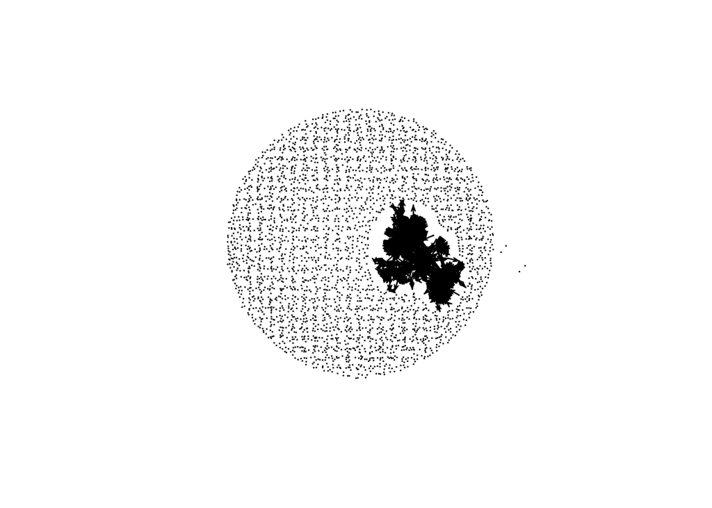

The graph shows a dense cluster of users with a high concentration of potentially connected gropus of mutually interacting pairs surrounded by a cloud of low interactivity.

#### Size

```r
net_raw
```

```
##  Network attributes:
##   vertices = 3660
##   directed = TRUE
##   hyper = FALSE
##   loops = FALSE
##   multiple = FALSE
##   bipartite = FALSE
##   total edges= 5268
##     missing edges= 0
##     non-missing edges= 5268
##
##  Vertex attribute names:
##     vertex.names
##
##  Edge attribute names not shown
```

The graph consists of 5268 edges, each representing one or more emails, an average of 1.4393443 emails per user.

#### Density

The graph has a density of 3.933709410^{-4}, which is very low.

#### Diameter

The diameter of the graph, 12, is the number of steps required to connect the two nodes furthest apart.

#### Clustering

The clustering coefficient of the graph is low, 0.0392917, indicating relatively few users who belong to interacting groups.

### Description of the reduced Enron graph

```
net <- delete.vertices(net_raw, isolates(net_raw))
```

#### Visualization

The contrast between the original and reduced graph (after removing isolates) is visually striking. Note that the edge line *length* does have any meaning; they vary solely to promote better visual discrimination.

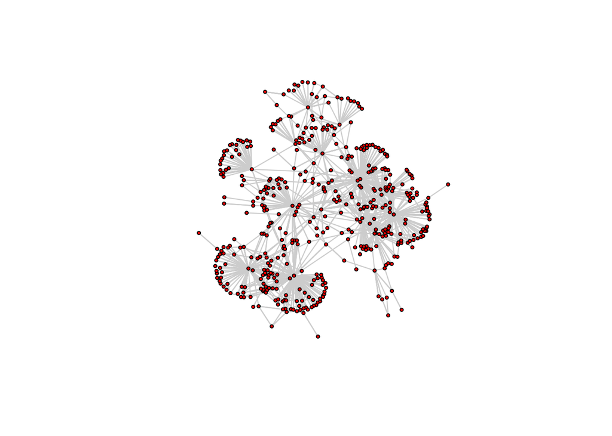

The reduced graph is the dense portion of the original, but some more readily discernable structure is apparent.

#### Density

The graph has a density of 0.024416, compared to the original graph, 3.933709410^{-4} or 62.0686874 greater.

#### Components

As seen in the visualization of the graph, only 1 member is weakly connected.

#### Diameter

The diameter of the graph, 12, the number of steps required to connect the two nodes furthest apart, is unchanged from the original.

#### Clustering

The clustering coefficient of the graph is low, 0.0392917, essentially identical to the original graph, indicating relatively few users who belong to interacting groups.

### Decomposition of the reduced Enron graph

Among the nodes represented in the visualization above, some have satellite nodes that connect principally to these center points. As a reminder, the length of the edge lines carries no meaning, nor the distance or proximity between dense portions of the graph. The rendering algorithm’s principal purpose is to spread out the links to promote visual clarity.

To identify these, measures of **centrality**. Three of those are `degree`, which measures aspects of the prominence of a node (user) in the network based on how many or few intermediates are required to reach any other node. The metric `betweenedness` representes how many connections between other nodes must pass through it to indirectly connect to nodes to which they are not directly connected. The third measure `infocent` measures the directness of a node to other nodes. Other measures of centrality exist, but the scope of this paper excludes a comparison among them.

Instead, the three were measured for each node in the reduced graph, giving them equal weight. The top 10% of nodes with high `degree` scores were selected, followed among those by the top 10% of high `betweenedness` scores, then high `infocent` scores to create a composite centrality indicator. Subsequent adjustments may improve the efficacy of the machine learning approach in this paper.

```r
load("prominence.Rda")
prominence %>% select(deg, btw, inf) %>% cor()
```

```
##           deg       btw       inf
## deg 1.0000000 0.4670800 0.4799712
## btw 0.4670800 1.0000000 0.5591332
## inf 0.4799712 0.5591332 1.0000000
```

```r
prominence
```

```
## # A tibble: 16 x 8
##     name  node   deg    btw   inf pareto_deg pareto_btw pareto_inf
##    <int> <int> <dbl>  <dbl> <dbl>      <dbl>      <dbl>      <dbl>
##  1    25  1648    65 14624.  1.32      0.946      0.969      0.996
##  2    47  1717   130  3057.  1.11      0.969      0.912      0.962
##  3    62  1790    76 19095.  1.21      0.951      0.980      0.978
##  4   119  2055    52  8640.  1.20      0.930      0.951      0.975
##  5   149  2168    46 14787.  1.09      0.924      0.971      0.960
##  6   152  2191   170 15536.  1.29      0.978      0.973      0.987
##  7   174  2276   480 19518.  1.32      0.989      0.982      0.993
##  8   186  2310   216  9992.  1.31      0.982      0.957      0.989
##  9   236  2575  1439  3538.  1.26      1.000      0.917      0.982
## 10   237  2576   859 77161.  1.31      0.993      0.998      0.991
## 11   300  2946    38  6258.  1.02      0.917      0.939      0.910
## 12   347  3146  1009 86520.  1.35      0.998      1.000      1.000
## 13   349  3152    84 10121.  1.07      0.953      0.962      0.946
## 14   374  3250    65 34146.  1.25      0.946      0.993      0.980
## 15   375  3255   429 54562.  1.34      0.987      0.996      0.998
## 16   404  3421   577 33634.  1.28      0.991      0.991      0.984
```

The three measures of prominence are correlated, to varying degrees, indicating that they are measuring the characteristic of centrality non-independently. Just 16 nodes are in the top 10% of centrality.

```r
load("centrals.Rda")
net_p <- network(prominence, matrix.type = "edgelist")
vertices <- network.vertex.names(net_p)
prominent <- g_enron %>% filter(f_userid %in% centrals | t_userid %in% centrals)
```

These 16 users are connected to 3405 other users. They account for 90.4517844% of the emails, as sender or receiver, in the reduced graph. Limiting the reduced graph to these central users results in the following graph.

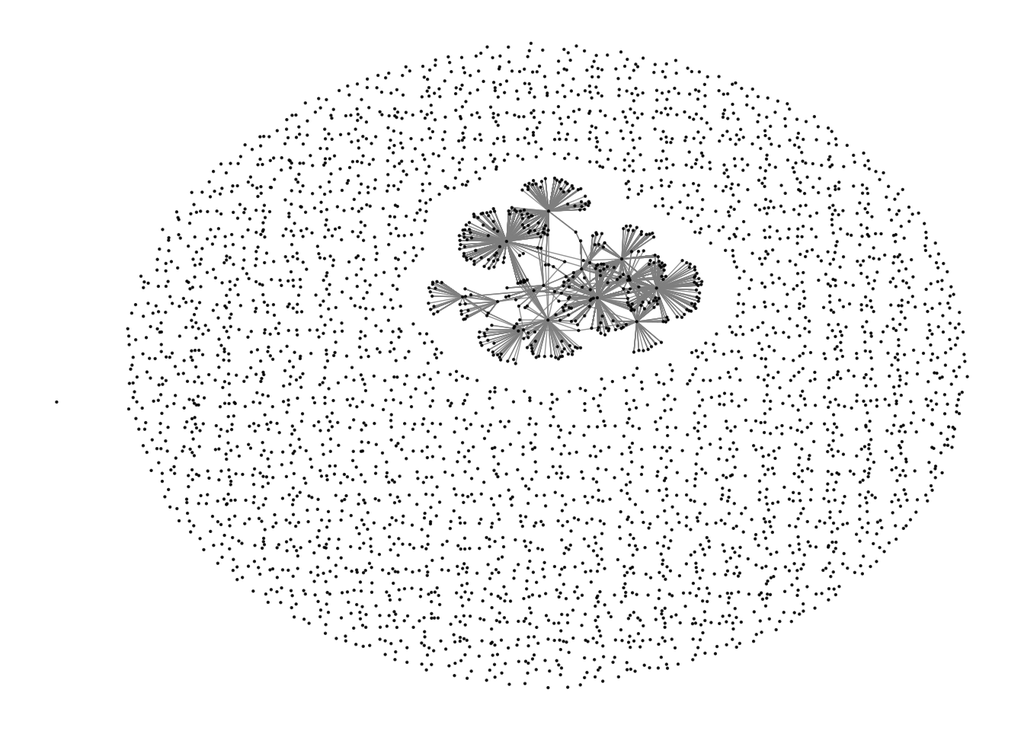

```r
load("prominent.Rda")
netmat <- prominent %>% select(t_userid, f_userid)
net_p <- network(netmat, matrix.type = "edgelist")
vertices <- network.vertex.names(net_p)
ggnet(net_p, size = 0.1, alpha = 0.84)
```

This visualization, like original graph, shows “noise” in the form of a cloud of poorly connected node pairs surrounding a denser inner core, even after senders and receivers were restricted to the most prominent users.

```r
net_p
```

```
##  Network attributes:
##   vertices = 3660
##   directed = TRUE
##   hyper = FALSE
##   loops = FALSE
##   multiple = FALSE
##   bipartite = FALSE
##   total edges= 4765
##     missing edges= 0
##     non-missing edges= 4765
##
##  Vertex attribute names:
##     vertex.names
##
##  Edge attribute names not shown
```

```r
vertices_before <- length(network.vertex.names(net_p))
```

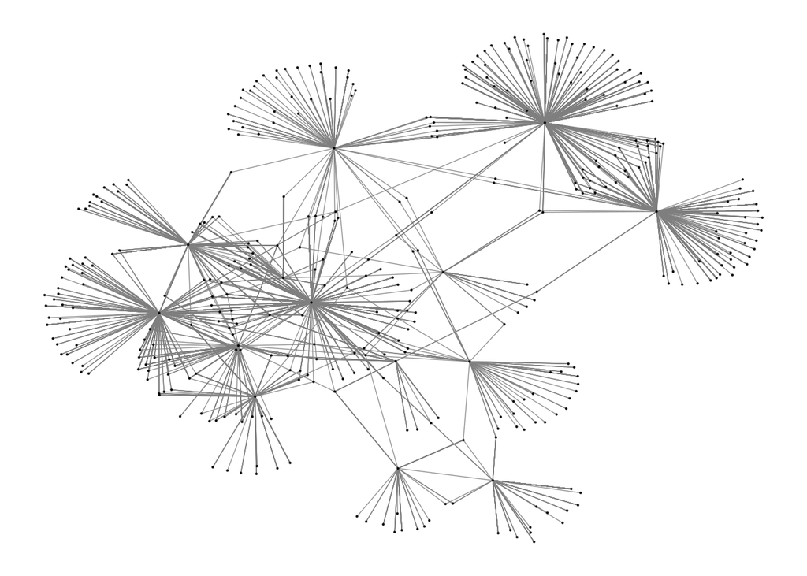

```r
delete.vertices(net_p, isolates(net_p))
vertices_after <- length(network.vertex.names(net_p))
ggnet(net_p, size = 0.1, alpha = 0.84)
```

Removing those outliers brings the core network into sharper relief by reducing the number of vertices, from 3660 to 399.

### Machine learning decomposition of the core network

Although the network has been reduced by inspection, the visualization of the result is ambiguous as to clusters of similar senders/recievers (nodes/edges). To validate the results, a machine learning tool is indicated. The [latentnet] package was selected for that task. An [accessible](https://www.ncbi.nlm.nih.gov/pmc/articles/PMC2831261/) description of that package, as well as a more [theoretical](https://www.jstatsoft.org/article/view/v024i05) paper are available for orientation.

The package applies exponential random graph modeling to the vertices, edges and optionally their attrtibutes to recursively dervive graph characteristics that are impractical to extract otherwise, due to the interdependence of graph measures.

#### Model creation

The first step is to fit a model to a network object:

```
  net_p.fit <- ergmm(net_p ~ euclidean(d=2, G=3), verbose = TRUE) # up to 30 minutes for 250 nodes
  Generating initial values for MCMC:
  Computing geodesic distances... Finished.
  Computing MDS locations... Finished.
  Computing other initial values... Finished.
  Finding the conditional posterior mode... Finished.
  Burning in... Finished.
  Starting sampling run... Finished.
  Post-processing the MCMC output:
  Performing label-switching... Finished.
  Fitting the MKL locations... Finished.
  Fitting MBC conditional on MKL locations... Finished.
```

The arguments to `ergmm` specify a negative Euclidian distance in 2-space for a three cluster grouping. The algorithm performs a Markov chain Monte Carlo simulation, the absolute row/column differences within the adjacency matrix to fit the Minimum Kullback-Liebler divergence statistic to produce model based clustering of the vertices in the graph.

```r
library(latentnet)
library(coda)
load("net_p.fit.Rda")
summary(net_p.fit)
```

```
##
## ==========================
## Summary of model fit
## ==========================
##
## Formula:   net_p ~ euclidean(d = 2, G = 3)
## Attribute: edges
## Model:     Bernoulli
## MCMC sample of size 4000, draws are 10 iterations apart, after burnin of 10000 iterations.
## Covariate coefficients posterior means:
##             Estimate    2.5%   97.5% 2*min(Pr(>0),Pr(<0))
## (Intercept)  -1.9744 -2.1183 -1.8386            < 2.2e-16 ***
## ---
## Signif. codes:  0 '***' 0.001 '**' 0.01 '*' 0.05 '.' 0.1 ' ' 1
##
## Overall BIC:        10914.77
## Likelihood BIC:     8384.658
## Latent space/clustering BIC:     2530.115
##
## Covariate coefficients MKL:
##              Estimate
## (Intercept) -3.315879
```

#### Model Diagnostics

Graphs do not uniformly converge under the `ergmm` function call. To test this, a diagnostic is available to detect failure of the Markov chain Monte Carlo simulation to converge and to detect autocorrelation effects. One section provides an initial and lag 10 covariance matrix of the sampling.

```r
library(latentnet)
library(coda)
load("net_p.fit.Rda")
mcmc.diagnostics(net_p.fit, which.diags = c("cor", "acf", "raftery"))
```

```
## Chain 1
## Lag 0
##               lpY      beta.1       Z.1.1       Z.1.2
## lpY    1.00000000  0.47541395  0.04536734  0.01857208
## beta.1 0.47541395  1.00000000  0.06473074 -0.05372611
## Z.1.1  0.04536734  0.06473074  1.00000000 -0.01356222
## Z.1.2  0.01857208 -0.05372611 -0.01356222  1.00000000
##
## Lag 10
##               lpY      beta.1      Z.1.1       Z.1.2
## lpY    0.60827334  0.43742187 0.04284890  0.01703367
## beta.1 0.44226482  0.71444735 0.04422307 -0.03119275
## Z.1.1  0.03936699  0.05665058 0.28978163  0.01203623
## Z.1.2  0.01927168 -0.02159930 0.02894825  0.24651351
```

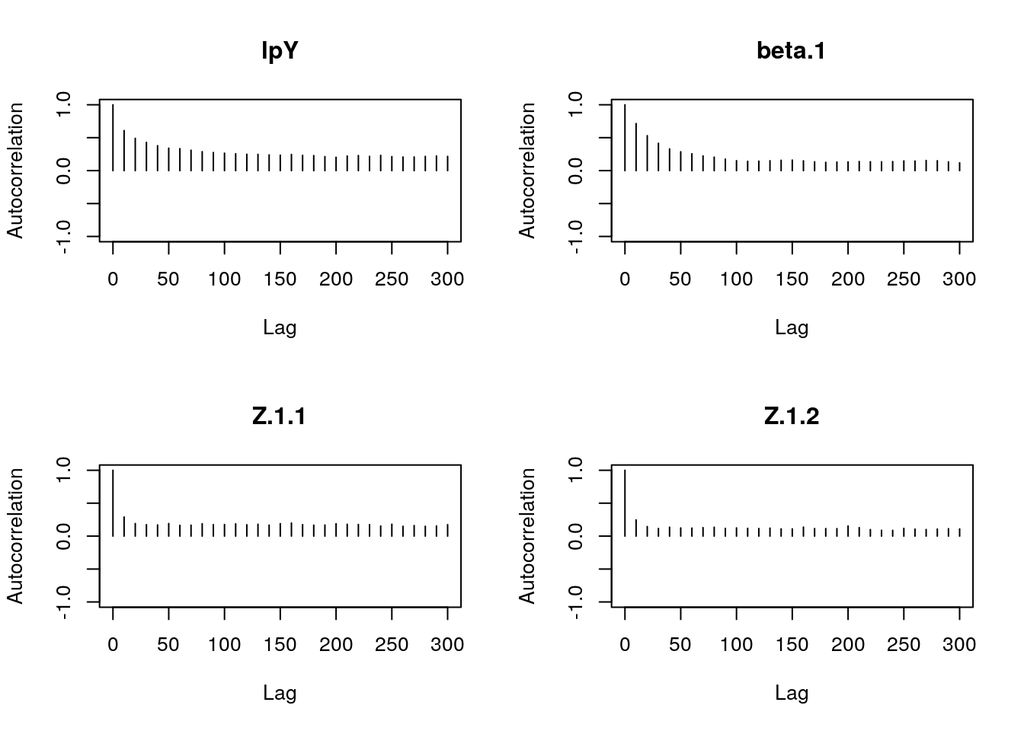

```
## [[1]]
##
## Quantile (q) = 0.025
## Accuracy (r) = +/- 0.0125
## Probability (s) = 0.95
##
##         Burn-in  Total Lower bound  Dependence
##         (M)      (N)   (Nmin)       factor (I)
##  lpY    50       9860  600          16.4
##  beta.1 100      17030 600          28.4
##  Z.1.1  40       7800  600          13.0
##  Z.1.2  20       6330  600          10.6
```

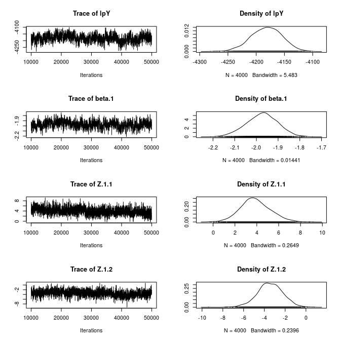

#### Goodness of fit

```r
net_p.gof <- gof(net_p.fit)
net_p.gof
```

```
##
## Goodness-of-fit for in-degree
##
##    obs min  mean max MC p-value
## 0   43  44 63.07  85       0.00
## 1  276  73 94.87 125       0.00
## 2   59  63 92.20 114       0.00
## 3    5  43 68.20  90       0.00
## 4    2  28 42.12  55       0.00
## 5    1  11 22.02  33       0.00
## 6    0   2  9.90  18       0.00
## 7    0   0  4.43   9       0.02
## 8    0   0  1.49   5       0.38
## 9    1   0  0.49   3       0.76
## 10   1   0  0.15   2       0.24
```

[output cut: 67 more lines]

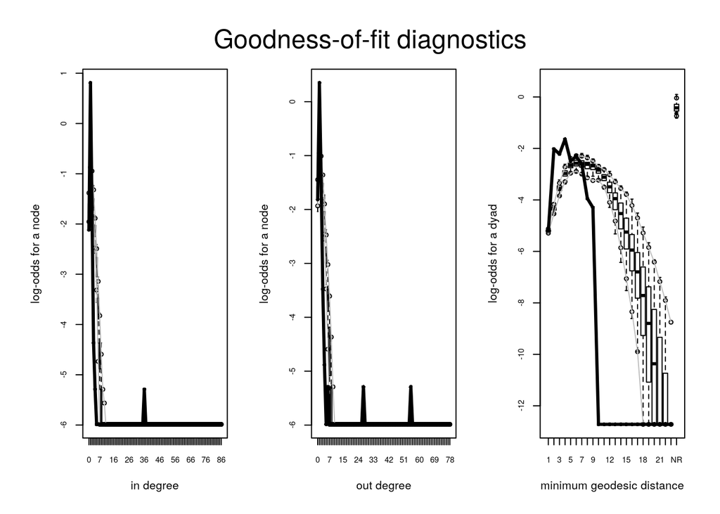

```r
par(mfrow=c(1,3))
par(oma=c(0.5,2,1,0.5))
plot(net_p.gof, plotlogodds=TRUE)
```

#### Visualization of model clusters, position within sample space and density

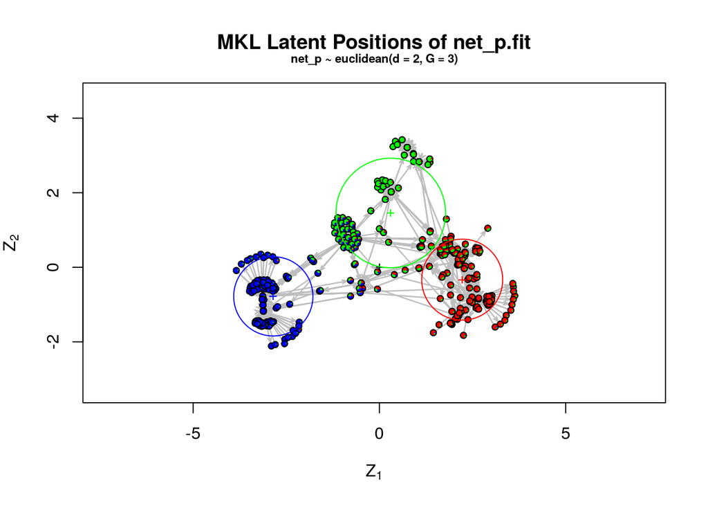

```r
plot(net_p.fit, pie=TRUE)
```

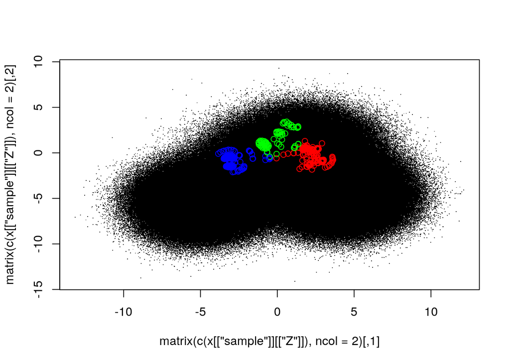

```r
plot(net_p.fit, what="cloud", rand.eff="receiver", Z.ref=Z.ref, Z.K.ref=Z.K.ref)
```

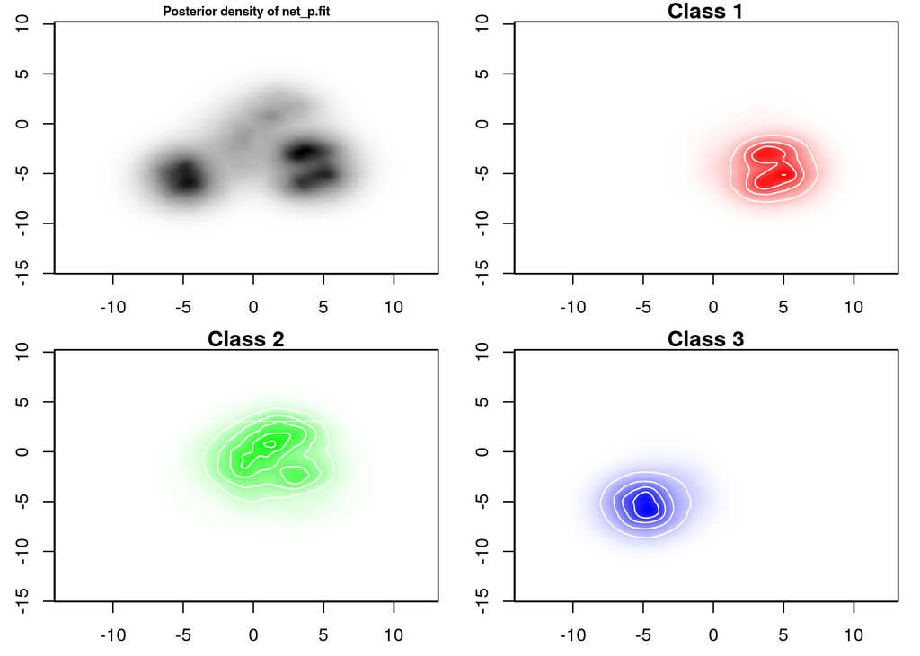

```r
plot(net_p.fit, what="density", rand.eff="receiver", Z.ref=Z.ref, Z.K.ref=Z.K.ref)
```

Using the cluster assignment to sender and recipient userids confirms the graph:

```r
load("n_enron.Rda")
n_enron %>% group_by(f_cluster, t_cluster) %>% count() %>% arrange(desc(n))
```

```
## # A tibble: 8 x 3
## # Groups:   f_cluster, t_cluster [8]
##   f_cluster t_cluster     n
##       <int>     <int> <int>
## 1         1         1  1913
## 2         3         3  1315
## 3         1         2   547
## 4         2         1   541
## 5         2         2   387
## 6         3         2    41
## 7         2         3    20
## 8         1         3     1
```

Members of cluster 1 correspond predominantly to other members of cluster 1 and to a substantial number of cluster 2 members. There is only one message from a cluster 1 member to a cluster 3 member. Cluster 2 members have an even division of emails sent to or received from cluster 1 and a smaller cluster 2 to cluster 2 correspondence. Correspondence between clusters 2 and 3, in either direction, is much less.

#### Application of the deconstruction of the Enron network

Through a combination of analytic judgment and machine learning a three-cluster partition of the emails has been created. The obvious question to now be addressed is what those clusters represent in terms of email content. For that the tools of natural language processing will be applied.

## Natural language processing

### The Enron vocabulary

```r
n1_text <- n_enron %>% filter(f_cluster == 1) %>% select(payload)
n2_text <- n_enron %>% filter(f_cluster == 2) %>% select(payload)
n3_text <- n_enron %>% filter(f_cluster == 3) %>% select(payload)
n1_words <- n1_text %>% unnest_tokens(word, payload)
n2_words <- n2_text %>% unnest_tokens(word, payload)
n3_words <- n3_text %>% unnest_tokens(word, payload)
```

Cluster 1 has the most words, 94013, followed by Cluster 3 with 44366 and Cluster 2 with 38956.

Superficially, there is little difference among the clusters with respect to their ten most frequent words.

```r
n1_words %>% count(word, sort = TRUE)
```

```
## # A tibble: 8,687 x 2
##    word      n
##    <chr> <int>
##  1 the    3164
##  2 to     2707
##  3 i      1902
##  4 you    1744
##  5 ect    1521
##  6 a      1416
##  7 and    1363
##  8 for    1038
##  9 is     1026
## 10 of     1003
## # … with 8,677 more rows
```

```r
n2_words %>% count(word, sort = TRUE)
```

```
## # A tibble: 5,537 x 2
##    word      n
##    <chr> <int>
##  1 the    1457
##  2 to     1285
##  3 i      1245
##  4 you    1011
##  5 and     804
##  6 a       669
##  7 that    553
##  8 of      552
##  9 in      497
## 10 for     470
## # … with 5,527 more rows
```

```r
n3_words %>% count(word, sort = TRUE)
```

```
## # A tibble: 4,680 x 2
##    word       n
##    <chr>  <int>
##  1 the     1638
##  2 to      1372
##  3 i        975
##  4 you      903
##  5 thanks   879
##  6 and      732
##  7 for      680
##  8 this     623
##  9 on       605
## 10 kim      603
## # … with 4,670 more rows
```

Some filtering is needed. This starts with subtracting a list of the most common words, such as *the* (**stopwords**). There are a variety of stopword lists. Some may be under-inclusive, removing only the most common parts of speech, while others may be over-inclusive, removing words that should be kept. For example, the word `not` often appears on lists of stopwords but is an important term in doing sentiment analysis using phrases – *not good* has a difference valence that *[blank] good*.

The `stop_word` data from the `tidytext` package was hand edited to exempt the following list of works:

```r
exempt_stopwords <- enframe(c("against", "all", "allow", "allows", "always", "awfully", "beforehand", "behind", "below", "better", "big", "can't", "cannot", "cant", "case", "cases", "downwards", "except", "gives", "good", "great", "highest", "hopefully", "immediate", "might", "necessary", "not", "nowhere", "numbers", "otherwise", "point", "serious", "seriously", "state", "states", "unfortunately", "value", "worked", "working", "zero"))
colnames(exempt_stopwords) <- c("line", "word")
stop_words <- anti_join(stop_words, exempt_stopwords)
```

- against
- all
- allow
- allows
- always
- awfully
- beforehand
- behind
- below
- better
- big
- can’t
- cannot
- cant
- case
- cases
- downwards
- except
- gives
- good
- great
- highest
- hopefully
- immediate
- might
- necessary
- not
- nowhere
- numbers
- otherwise
- point
- serious
- seriously
- state
- states
- unfortunately
- value
- worked
- working
- zero

and to add `ect`, `hou` and `enronxgate`.

```r
add_stops <- c("ect", "hou", "enronxgate")
lexicon <- c("user", "user", "user")
new_stops <- cbind(add_stops, lexicon)
colnames(new_stops) <- c("word", "lexicon")
new_stops <- as_tibble(new_stops)
stop_words <- rbind(stop_words, new_stops)
```

Here are the top 25 words in each cluster, after removing the adjusted stopwords and numbers.

```r
n1_text <- n_enron %>% filter(f_cluster == 1) %>% select(payload)
n2_text <- n_enron %>% filter(f_cluster == 2) %>% select(payload)
n3_text <- n_enron %>% filter(f_cluster == 3) %>% select(payload)

n1_words <- n1_text %>%
            unnest_tokens(word, payload) %>%
            anti_join(stop_words) %>%
            filter(word != str_match_all(word,"^\\d+"))

n2_words <- n2_text %>%
            unnest_tokens(word, payload) %>%
            anti_join(stop_words) %>%
            filter(word != str_match_all(word,"^\\d+"))


n3_words <- n3_text %>%
            unnest_tokens(word, payload) %>%
            anti_join(stop_words) %>%
            filter(word != str_match_all(word,"^\\d+"))


n1_words %>% count(word, sort = TRUE) %>% print(n = 50)
```

```
## # A tibble: 7,364 x 2
##    word           n
##    <chr>      <int>
##  1 enron        976
##  2 john         578
##  3 not          485
##  4 cc           390
##  5 subject      390
##  6 errol        309
##  7 arnold       281
##  8 pm           227
##  9 gas          225
## 10 all          209
## 11 corp         198
## 12 deals        188
```

[output cut: 39 more lines]

```r
n2_words %>% count(word, sort = TRUE) %>% print(n = 25)
```

```
## # A tibble: 4,732 x 2
##    word          n
##    <chr>     <int>
##  1 not         247
##  2 enron       230
##  3 all         130
##  4 time         93
##  5 call         71
##  6 deal         69
##  7 ken          63
##  8 dg           57
##  9 good         56
## 10 company      49
## 11 day          46
## 12 can't        44
## 13 business     42
## 14 deals        39
## 15 great        38
## 16 people       38
## 17 meeting      35
## 18 working      34
## 19 questions    33
## 20 week         33
## 21 hope         32
## 22 employees    31
## 23 don          30
## 24 gas          30
## 25 talk         30
## # … with 4,707 more rows
```

```r
n3_words %>% count(word, sort = TRUE) %>% print(n = 25)
```

```
## # A tibble: 3,931 x 2
##    word        n
##    <chr>   <int>
##  1 kim       603
##  2 lynn      522
##  3 enron     414
##  4 fyi       204
##  5 meeting   194
##  6 not       179
##  7 ava       126
##  8 tw        115
##  9 all       103
## 10 gas        96
## 11 time       96
## 12 john       95
## 13 steve      91
## 14 call       87
## 15 week       80
## 16 audrey     75
## 17 day        72
## 18 discuss    68
## 19 office     65
## 20 team       62
## 21 good       61
## 22 terry      60
## 23 send       57
## 24 morning    55
## 25 nng        55
## # … with 3,906 more rows
```